# 206 A5 Q4

Barbara Rose Hoover

12/4/2018

```r
library(tidyverse)
library(stargazer)
library(MASS)
faculty <- read_csv("Faculty.csv")
faculty <- rename(faculty, discipline = `Discipline (A = Theoretical, B = Applied)`, rank = `Faculty Rank`, yearsphd = `Years Since PhD`, yearsfac = `Years Faculty Service`, sex = Sex, salary = `Salary ($)`)
```

Linear Model

```r
salary_lm <- lm(salary ~ rank + discipline + yearsphd + yearsfac + sex, data = faculty)
summary(salary_lm)
```

```
##
## Call:
## lm(formula = salary ~ rank + discipline + yearsphd + yearsfac +
##     sex, data = faculty)
##
## Residuals:
##    Min     1Q Median     3Q    Max
## -65248 -13211  -1775  10384  99592
##
## Coefficients:
##              Estimate Std. Error t value Pr(>|t|)
## (Intercept)   78862.8     4990.3  15.803  < 2e-16 ***
## rankAsstProf -12907.6     4145.3  -3.114  0.00198 **
## rankProf      32158.4     3540.6   9.083  < 2e-16 ***
## disciplineB   14417.6     2342.9   6.154 1.88e-09 ***
## yearsphd        535.1      241.0   2.220  0.02698 *
## yearsfac       -489.5      211.9  -2.310  0.02143 *
## sexMale        4783.5     3858.7   1.240  0.21584
## ---
## Signif. codes:  0 '***' 0.001 '**' 0.01 '*' 0.05 '.' 0.1 ' ' 1
##
## Residual standard error: 22540 on 390 degrees of freedom
## Multiple R-squared:  0.4547, Adjusted R-squared:  0.4463
## F-statistic:  54.2 on 6 and 390 DF,  p-value: < 2.2e-16
```

```r
#p-value for sex 0.21584
```

```r
salary5_lm<-lm(salary ~ rank + discipline, data = faculty)
summary(salary5_lm)
```

```
##
## Call:
## lm(formula = salary ~ rank + discipline, data = faculty)
##
## Residuals:
##    Min     1Q Median     3Q    Max
## -65990 -14049  -1288  10760  97996
##
## Coefficients:
##              Estimate Std. Error t value Pr(>|t|)
## (Intercept)     85706       3142  27.273  < 2e-16 ***
## rankAsstProf   -13762       3961  -3.475 0.000569 ***
## rankProf        34082       3160  10.786  < 2e-16 ***
## disciplineB     13761       2296   5.993 4.65e-09 ***
## ---
## Signif. codes:  0 '***' 0.001 '**' 0.01 '*' 0.05 '.' 0.1 ' ' 1
##
## Residual standard error: 22650 on 393 degrees of freedom
## Multiple R-squared:  0.445,  Adjusted R-squared:  0.4407
## F-statistic:   105 on 3 and 393 DF,  p-value: < 2.2e-16
```

```r
AIC(salary5_lm)
```

```
## [1] 9094.823
```

```r
salary2_lm<-lm(salary ~ rank + discipline + sex, data = faculty)
summary(salary2_lm)
```

```
##
## Call:
## lm(formula = salary ~ rank + discipline + sex, data = faculty)
##
## Residuals:
##    Min     1Q Median     3Q    Max
## -66268 -14127  -1566  10813  97718
##
## Coefficients:
##              Estimate Std. Error t value Pr(>|t|)
## (Intercept)     81947       4506  18.187  < 2e-16 ***
## rankAsstProf   -13723       3959  -3.466 0.000586 ***
## rankProf        33680       3177  10.600  < 2e-16 ***
## disciplineB     13709       2295   5.972 5.25e-09 ***
## sexMale          4492       3860   1.164 0.245291
## ---
## Signif. codes:  0 '***' 0.001 '**' 0.01 '*' 0.05 '.' 0.1 ' ' 1
##
## Residual standard error: 22640 on 392 degrees of freedom
## Multiple R-squared:  0.4469, Adjusted R-squared:  0.4412
## F-statistic: 79.18 on 4 and 392 DF,  p-value: < 2.2e-16
```

### lm was run for a version including both rank and yearsphd, and one for only including rank. Resulting adjusted R^2 was 0.4401, 0.4412 and the AIC was 9097.22, 9095.454 respectively. Seeing as adjusted R^2 was not improved with the additional variable, yearsphd was dropped from the final model.

### Although the p-value for gender was not significant in the final model (p=0.245291), gender was included because gender accounts for a $4492 difference in salary. This fact is significant because this means that with all other variables constant, females will be paid $4492 less then men.

```r
salary3_lm<-lm(salary ~ rank + discipline + yearsphd + sex, data = faculty)
summary(salary3_lm)
```

```
##
## Call:
## lm(formula = salary ~ rank + discipline + yearsphd + sex, data = faculty)
##
## Residuals:
##    Min     1Q Median     3Q    Max
## -67451 -13860  -1549  10716  97023
##
## Coefficients:
##               Estimate Std. Error t value Pr(>|t|)
## (Intercept)   80988.47    4931.84  16.422  < 2e-16 ***
## rankAsstProf -13104.15    4167.31  -3.145  0.00179 **
## rankProf      32928.40    3544.40   9.290  < 2e-16 ***
## disciplineB   13937.47    2346.53   5.940 6.32e-09 ***
## yearsphd         61.01     127.01   0.480  0.63124
## sexMale        4349.37    3875.39   1.122  0.26242
## ---
## Signif. codes:  0 '***' 0.001 '**' 0.01 '*' 0.05 '.' 0.1 ' ' 1
##
## Residual standard error: 22660 on 391 degrees of freedom
## Multiple R-squared:  0.4472, Adjusted R-squared:  0.4401
## F-statistic: 63.27 on 5 and 391 DF,  p-value: < 2.2e-16
```

```r
salary4_lm<-lm(salary ~ rank + discipline + yearsfac + sex, data = faculty)
summary(salary4_lm)
```

```
##
## Call:
## lm(formula = salary ~ rank + discipline + yearsfac + sex, data = faculty)
##
## Residuals:
##    Min     1Q Median     3Q    Max
## -64202 -14255  -1533  10571  99163
##
## Coefficients:
##               Estimate Std. Error t value Pr(>|t|)
## (Intercept)   82912.07    4668.39  17.760  < 2e-16 ***
## rankAsstProf -14560.40    4098.32  -3.553 0.000428 ***
## rankProf      34599.24    3382.52  10.229  < 2e-16 ***
## disciplineB   13473.38    2315.50   5.819 1.24e-08 ***
## yearsfac        -88.78     111.64  -0.795 0.426958
## sexMale        4771.25    3878.00   1.230 0.219311
## ---
## Signif. codes:  0 '***' 0.001 '**' 0.01 '*' 0.05 '.' 0.1 ' ' 1
##
## Residual standard error: 22650 on 391 degrees of freedom
## Multiple R-squared:  0.4478, Adjusted R-squared:  0.4407
## F-statistic: 63.41 on 5 and 391 DF,  p-value: < 2.2e-16
```

```r
#negative coefficient for yearsfac. Does not make sense
```

```r
AIC(salary_lm) #9093.826, 0.4547, 0.4463
```

```
## [1] 9093.826
```

```r
AIC(salary2_lm) #9095.454, 0.4469, 0.4412 <-choose this one
```

```
## [1] 9095.454
```

```r
AIC(salary3_lm) #9097.22, 0.4472, 0.4401
```

```
## [1] 9097.22
```

```r
AIC(salary4_lm) #9096.813, 0.4478, 0.4407
```

```
## [1] 9096.813
```

```r
AIC(salary5_lm) #9094.823, 0.445, 0.4407 <- Possibly compare. Model excludes gender
```

```
## [1] 9094.823
```

```r
stargazer(salary2_lm,
          type = 'latex',
          title = "Iris regression results.")
```

[output not shown]

### Exploring rank, yearsfac, yearsphd

```r
rank_lm<-lm(salary ~ rank + discipline  + sex, data = faculty)
summary(rank_lm)
```

```
##
## Call:
## lm(formula = salary ~ rank + discipline + sex, data = faculty)
##
## Residuals:
##    Min     1Q Median     3Q    Max
## -66268 -14127  -1566  10813  97718
##
## Coefficients:
##              Estimate Std. Error t value Pr(>|t|)
## (Intercept)     81947       4506  18.187  < 2e-16 ***
## rankAsstProf   -13723       3959  -3.466 0.000586 ***
## rankProf        33680       3177  10.600  < 2e-16 ***
## disciplineB     13709       2295   5.972 5.25e-09 ***
## sexMale          4492       3860   1.164 0.245291
## ---
## Signif. codes:  0 '***' 0.001 '**' 0.01 '*' 0.05 '.' 0.1 ' ' 1
##
## Residual standard error: 22640 on 392 degrees of freedom
## Multiple R-squared:  0.4469, Adjusted R-squared:  0.4412
## F-statistic: 79.18 on 4 and 392 DF,  p-value: < 2.2e-16
```

```r
rank_lm2<-lm(salary ~ yearsfac + discipline  + sex, data = faculty)
summary(rank_lm2)
```

```
##
## Call:
## lm(formula = salary ~ yearsfac + discipline + sex, data = faculty)
##
## Residuals:
##    Min     1Q Median     3Q    Max
## -77424 -19404  -4635  15539 105391
##
## Coefficients:
##             Estimate Std. Error t value Pr(>|t|)
## (Intercept)  84361.1     4941.4  17.072  < 2e-16 ***
## yearsfac       832.2      110.2   7.550 3.07e-13 ***
## disciplineB  13033.8     2840.3   4.589 6.01e-06 ***
## sexMale       8423.3     4744.5   1.775   0.0766 .
## ---
## Signif. codes:  0 '***' 0.001 '**' 0.01 '*' 0.05 '.' 0.1 ' ' 1
##
## Residual standard error: 27790 on 393 degrees of freedom
## Multiple R-squared:  0.1646, Adjusted R-squared:  0.1582
## F-statistic: 25.81 on 3 and 393 DF,  p-value: 2.928e-15
```

```r
rank_lm3<-lm(salary ~ yearsphd + discipline  + sex, data = faculty)
summary(rank_lm3)
```

```
##
## Call:
## lm(formula = salary ~ yearsphd + discipline + sex, data = faculty)
##
## Residuals:
##    Min     1Q Median     3Q    Max
## -79850 -17491  -3639  15485  92883
##
## Coefficients:
##             Estimate Std. Error t value Pr(>|t|)
## (Intercept)  74535.1     4932.1  15.112  < 2e-16 ***
## yearsphd      1093.3      106.8  10.232  < 2e-16 ***
## disciplineB  15626.3     2730.4   5.723 2.08e-08 ***
## sexMale       6956.3     4509.2   1.543    0.124
## ---
## Signif. codes:  0 '***' 0.001 '**' 0.01 '*' 0.05 '.' 0.1 ' ' 1
##
## Residual standard error: 26420 on 393 degrees of freedom
## Multiple R-squared:  0.2447, Adjusted R-squared:  0.2389
## F-statistic: 42.43 on 3 and 393 DF,  p-value: < 2.2e-16
```

# Data Exploration

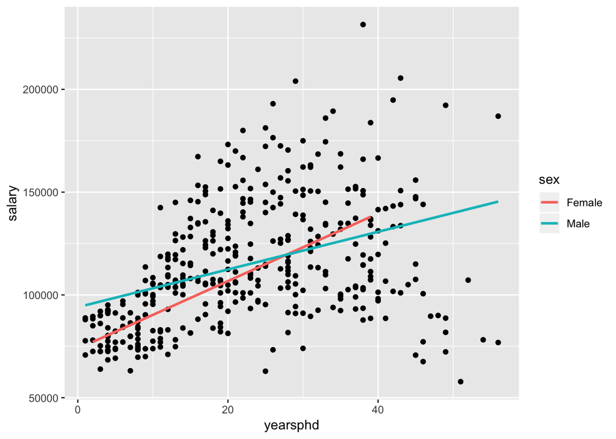

```r
plt<-ggplot(faculty, aes(y=salary, x=yearsphd, group=sex))+
  geom_point()+
  geom_smooth(method = "lm", se = FALSE, aes(color=sex))
plt
```

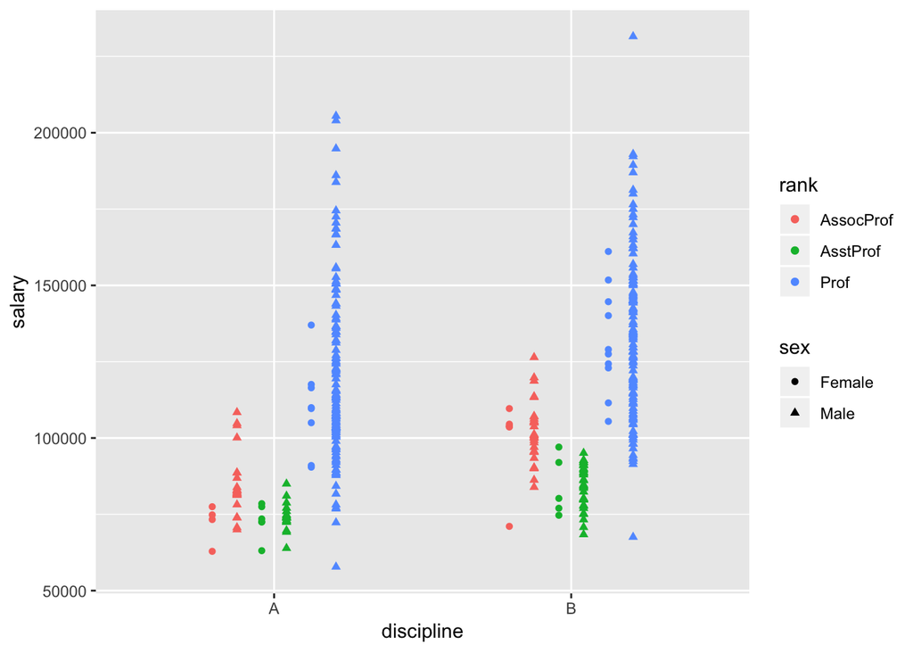

```r
plt2<-ggplot(faculty, group=discipline)+
  geom_point(aes(x=discipline, y=salary, color=rank, shape=sex), position=position_dodge(width = .5))
plt2
```

# Exploring dependence

```r
#Rank is not independent of gender. This is something to consider.
t.rank<-table(faculty$sex, faculty$rank)
ct<-chisq.test(t.rank)
ct$expected
```

```
##
##          AssocProf  AsstProf      Prof
##   Female  6.287154  6.581864  26.13098
##   Male   57.712846 60.418136 239.86902
```

```r
ct$observed
```

```
##
##          AssocProf AsstProf Prof
##   Female        10       11   18
##   Male          54       56  248
```

```r
ct$stdres
```

```
##
##          AssocProf  AsstProf      Prof
##   Female  1.702577  1.989100 -2.915939
##   Male   -1.702577 -1.989100  2.915939
```

```r
ct ##p-value = 0.01408
```

```
##
##  Pearson's Chi-squared test
##
## data:  t.rank
## X-squared = 8.5259, df = 2, p-value = 0.01408
```

```r
##years fac vs. years phd
cor(faculty$yearsphd, faculty$yearsfac)
```

```
## [1] 0.9096491
```

```r
#0.9096491
```

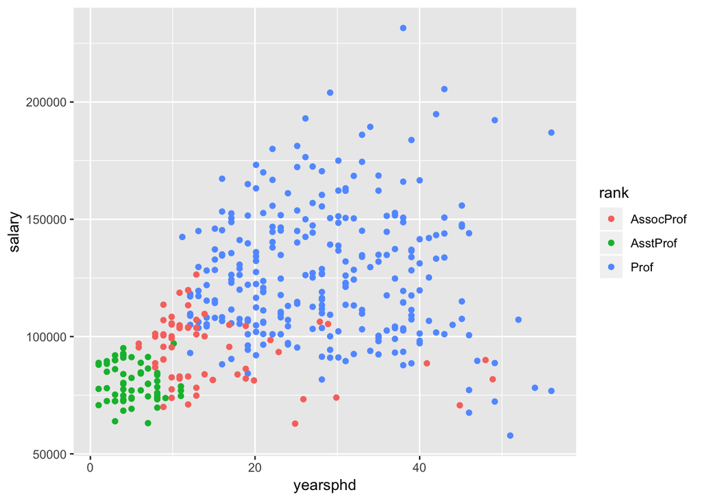

```r
plt4<-ggplot(faculty, group=rank)+
  geom_point(aes(x=yearsphd, y=salary, color=rank), position=position_dodge(width = .5))
plt4
```

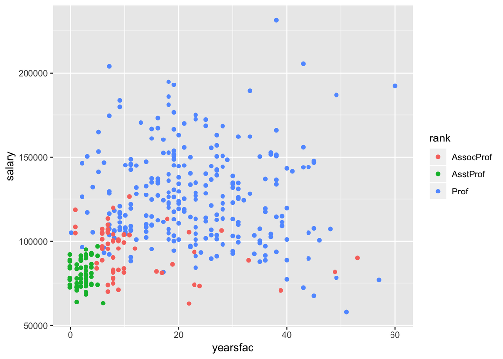

```r
plt5<-ggplot(faculty, group=rank)+
  geom_point(aes(x=yearsfac, y=salary, color=rank), position=position_dodge(width = .5))
plt5
```